# Final Project - Bakery Transaction

Shuoqi Zhang, Yijing(Trista) Lin

11/30/2020

```r
#Include the libraries we are going to need here
library(caret)
```

```r
library(ggplot2)
library(plyr)
#library(tidyr)
library(tidyverse)
library(ggcorrplot)
library(knitr)
library(splines)
library(glmnet)
library(gridExtra)
library(grid)
library(RColorBrewer)
nb.cols <- 18
mycolors <- colorRampPalette(brewer.pal(8, "Blues"))(nb.cols)
cookiecol<-c('#ad6a1d','#9a5327','#cc8d4a','#4e1703','#ecc78d','#2e0a05','#d0dfe4','#33575b', '#173742')
```

#1 Background

The main dataset is the transaction record of a bakery (https://www.kaggle.com/sulmansarwar/transactions-from-a-bakery). Though not specified in the description of the dataset, it is implied that this bakery is located in the old town of Edinburgh, UK. The dataset is downloaded from kaggle and stored under the same path as this R markdown file.

In order to supplement the dataset with more features, we extract the historical weather records from Meteostat (https://dev.meteostat.net/python/hourly.html#response-parameters). We use the weather data recorded by a weather station in Edinburgh Airport, which is about 8 miles away from the Edinburgh old town. The dataset is downloaded and stored under the same path of this R markdown file.

#2 Questions To Be Answered

#3 Data Cleaning and Wrangling

## 3.1 Read The Dataset

Firstly we will read the dataset of the bakery transaction record, and the hourly weather record in Edinburgh.

```r
df_ori <- read.csv(file = 'BreadBasket_DMS.csv',
               header = TRUE,
               encoding = 'utf-8')

df_weather_ori <- read.csv(file = 'Edinburgh_weather_hourly.csv',
                       header = TRUE,
                       encoding = 'utf-8')
```

Then we display the first few rows of each data set.

```r
head(df_ori)
```

```
##         Date     Time Transaction          Item
## 1 2016-10-30 09:58:11           1         Bread
## 2 2016-10-30 10:05:34           2  Scandinavian
## 3 2016-10-30 10:05:34           2  Scandinavian
## 4 2016-10-30 10:07:57           3 Hot chocolate
## 5 2016-10-30 10:07:57           3           Jam
## 6 2016-10-30 10:07:57           3       Cookies
```

```r
head(df_weather_ori)
```

```
##            time temp dwpt rhum prcp snow wdir wspd wpgt pres tsun coco station
## 1 1/1/2016 0:00    2  0.1   87   NA   NA   NA   NA   NA 1013   NA   NA    3160
## 2 1/1/2016 1:00    2  0.1   87   NA   NA  240 22.3   NA 1014   NA   NA    3160
## 3 1/1/2016 2:00    2  0.1   87   NA   NA  230 25.9   NA 1015   NA   NA    3160
## 4 1/1/2016 3:00    3 -1.0   75   NA   NA  230 20.5   NA 1015   NA   NA    3160
## 5 1/1/2016 4:00    2 -2.0   75   NA   NA  240  9.4   NA 1016   NA   NA    3160
## 6 1/1/2016 5:00    2 -2.0   75   NA   NA   NA  3.6   NA 1016   NA   NA    3160
```

We will create the keys in order to merge two datasets.

```r
df <- df_ori
df_weather <- df_weather_ori
df$Date <- as.Date(df$Date, "%Y-%m-%d")
df$Hour <- as.numeric(substr(df$Time, 1, 2))
df$key <- paste(as.character(df$Date), "@", as.character(df$Hour))
df_weather <- df_weather %>% separate(time, c("Date", "Hour_Minute"), " ")
df_weather <- df_weather %>% separate(Hour_Minute, c("Hour", "Minute"), ":")
df_weather$Date <- as.Date(df_weather$Date, "%m/%d/%Y")
df_weather$Hour <- as.numeric(df_weather$Hour)
df_weather$key <- paste(as.character(df_weather$Date), "@", as.character(df_weather$Hour))
```

## 3.2 The Bakery Transaction Record

### 3.2.1 NA Values and Duplicated Rows

Now we will deal with the data type and missing values, if any. We will start with the bakery transaction record database.

```r
summary(df)
```

```
##       Date                  Time        Transaction        Item
##  Min.   :2016-10-30   12:07:39:   16   Min.   :   1   Coffee :5471
##  1st Qu.:2016-12-03   10:45:21:   13   1st Qu.:2548   Bread  :3325
##  Median :2017-01-21   10:55:19:   13   Median :5067   Tea    :1435
##  Mean   :2017-01-17   14:38:01:   13   Mean   :4952   Cake   :1025
##  3rd Qu.:2017-02-28   13:43:08:   12   3rd Qu.:7329   Pastry : 856
##  Max.   :2017-04-09   14:19:47:   12   Max.   :9684   NONE   : 786
##                       (Other) :21214                  (Other):8395
##       Hour           key
##  Min.   : 1.00   Length:21293
##  1st Qu.:10.00   Class :character
##  Median :12.00   Mode  :character
##  Mean   :12.25
##  3rd Qu.:14.00
##  Max.   :23.00
##
```

There is no NAs. Then we will verify whether there are duplicated rows in the dataset

```r
dim(df[duplicated(df), ])[1]
```

```
## [1] 1653
```

There are duplicated rows. Considering that our analysis will not focus on the quantities of item sold, it is OK to remove those duplicated rows.

```r
df <- distinct(df)
```

### 3.2.2 Weekday vs. Weekend

Given the nature of the bakery business, we may expect different behaviors during weekdays and weekends.

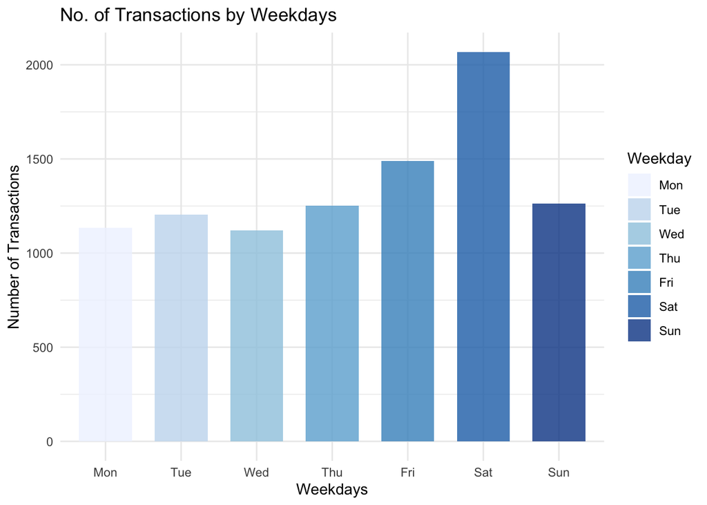

```r
df$Weekday <- weekdays(df$Date, abbreviate = TRUE)

df$Weekday <- factor(df$Weekday,
                        levels = c('Mon', 'Tue', 'Wed', 'Thu', 'Fri', 'Sat', 'Sun'))


res <- ddply(df, ~Weekday, summarise, No_of_transaction = length(unique(Transaction)))

ggplot(data = res, mapping = aes(x = Weekday, y = No_of_transaction, fill = Weekday)) +
  geom_bar(stat = 'identity',width=0.7,alpha=0.8) +
  labs(title = 'No. of Transactions by Weekdays', x = 'Weekdays', y = 'Number of Transactions') +
  scale_fill_brewer(palette = "Blues") +
  theme_minimal()
```

As expected, there are more transactions on Saturday. However, the number of transactions on Sunday seem to be low. To further understand what happened, we will look at the number of transactions by hour by weekdays.

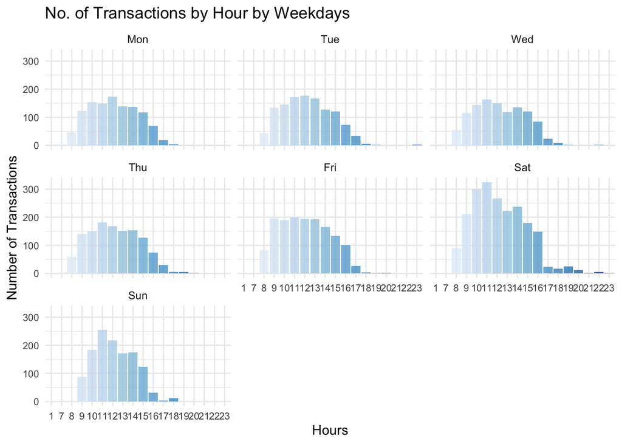

```r
res <- ddply(df, .(Weekday, Hour), summarise, No_of_transaction = length(unique(Transaction)))

ggplot(data = res, mapping = aes(x = as.factor(Hour), y = No_of_transaction, fill = as.factor(Hour))) +
  geom_bar(stat = "identity",alpha=0.8) + facet_wrap(~ Weekday) +
  labs(title = 'No. of Transactions by Hour by Weekdays', x = 'Hours', y = 'Number of Transactions') +
  scale_fill_manual(values = mycolors) +
  theme_minimal() +
  theme(legend.position = "none",
axis.text = element_text(size=8),
)
```

Looking at the distribution of transactions by hours, we noticed that the trend for Saturday and Sunday are similar and are different from the ones of the other days. Therefore, it makes sense to group Saturday and Sunday together, though Sunday has less transactions comparing with Saturday.

```r
df$Weekend <- mapvalues(df$Weekday,
                        from = c('Mon', 'Tue', 'Wed', 'Thu', 'Fri', 'Sat', 'Sun'),
                        to = c(0, 0, 0, 0, 0, 1, 1))

df$Weekend <- as.numeric(as.character(df$Weekend))
```

### 3.2.3 Hours of The Day

From the figure presented in 3.2.2, we noticed that there are few transactions associated with abnormal hours, such as 1 am and 11 pm.

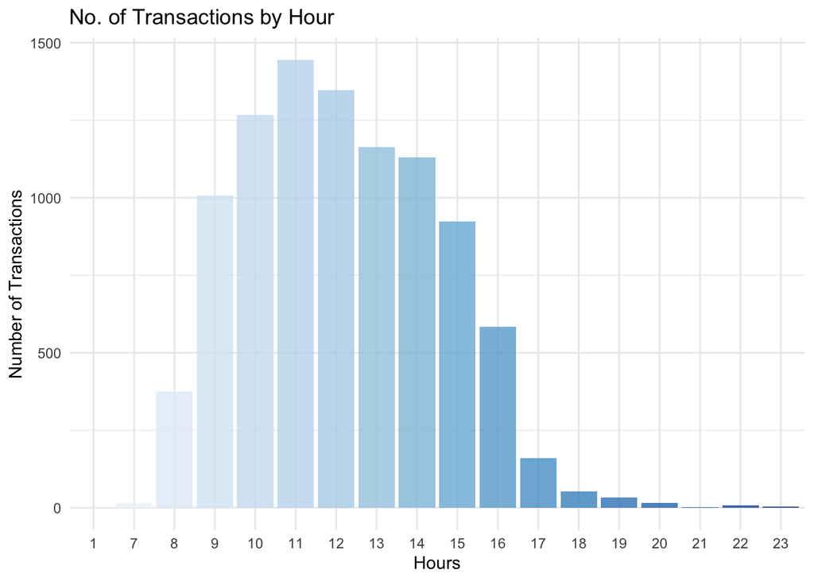

```r
res <- ddply(df, ~Hour, summarise, No_of_transaction = length(unique(Transaction)))
ggplot(data = res, mapping = aes(x = as.factor(Hour), y = No_of_transaction, fill = as.factor(Hour))) +
  geom_bar(stat = 'identity',alpha=0.8) +
  labs(title = 'No. of Transactions by Hour', x = 'Hours', y = 'Number of Transactions') +
  scale_fill_manual(values = mycolors) +
  theme_minimal() +
  theme(legend.position = "none")
```

Considering the small amount of transactions associated with abnormal hours, we will drop the rows whose hours is outside a normal business operating time. In other words, we will drop rows whose hour is 1, 21, 22, or 23 from our dataset.

```r
df <- df%>%filter(Hour<21&Hour>1)
```

Another observation is that the amount of transaction within an hour varies by the time of the day. Here we split the day into two segments: rush hours from 9 to 15 and non-rush hours for the rest of the day. Such split makes sense practically as the period from 9 to 15 covers breakfast, lunch, and coffee or tea time in the afternoon.

```r
df$Rush_hours <- mapvalues(df$Hour,
                        from = c(7, 8,
                                 9, 10, 11, 12, 13, 14, 15,
                                 16, 17, 18, 19, 20),
                        to = c(0, 0,
                               1, 1, 1, 1, 1, 1, 1,
                               0, 0, 0, 0, 0))
```

### 3.2.4 Holidays

We also want to take a look at sales during holidays. We will focus on two holidays, Christmas and New Year. 0 = non-holiday 1 = Christmas|New Year （12/24/2016 - 1/1/2017) Bakery did not open on 12/25/2016, 12/26/2016, 1/1/2017

```r
df$Holiday<-0
df$Holiday[df$Date>'2016-12-23'&df$Date<'2017-01-02']<-1
hol<-df%>%group_by(Holiday)%>%summarize(mean_transaction = length(unique(Transaction))/length(unique(Date)))
```

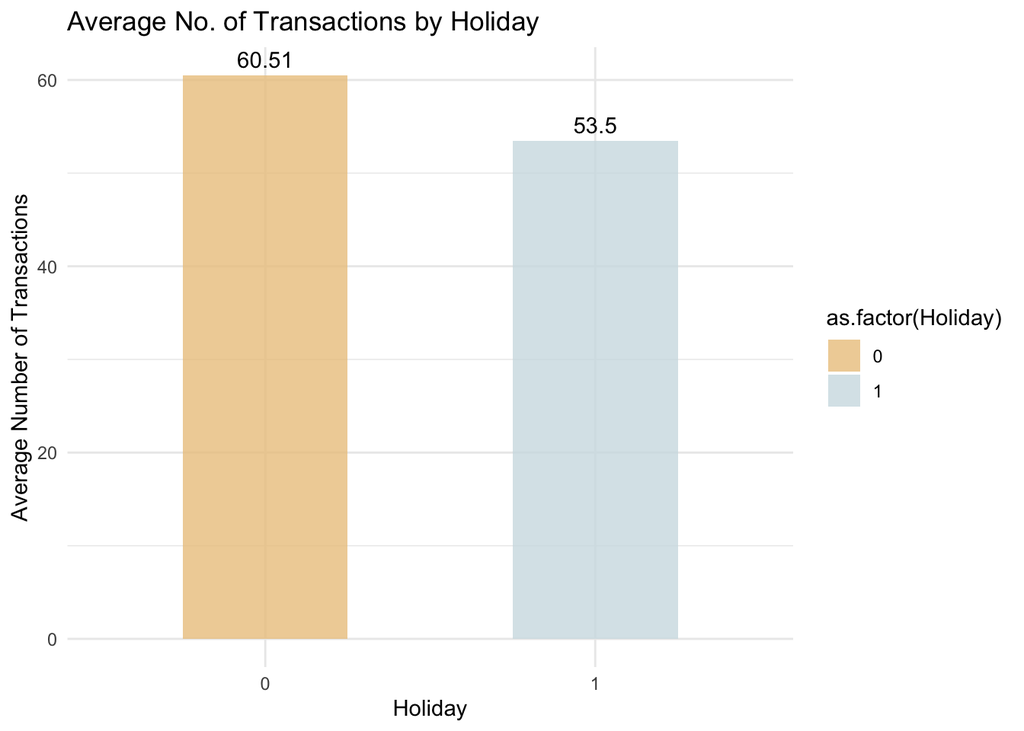

```r
hol%>%ggplot(aes(as.factor(Holiday),mean_transaction, fill = as.factor(Holiday),label = round(mean_transaction,2))) +
  labs(title = 'Average No. of Transactions by Holiday', x = 'Holiday', y = 'Average Number of Transactions') +
  geom_bar(stat = 'identity', width = 0.5,alpha=0.8) +
  geom_text(vjust = -0.5) +
  scale_fill_manual(values = cookiecol[c(5,7)]) +
  theme_minimal()
```

Indeed, the average number of transaction on holidays is 12% less than the one of non-holidays.

### 3.2.5 List of Purchased Items

Then we will focus on the “Item” column to understand what are included.

```r
Item_tb <- table(df$Item)
sort(Item_tb, decreasing = TRUE)
```

```
##
##                        Coffee                         Bread
##                          4528                          3096
##                           Tea                          Cake
##                          1350                           983
##                        Pastry                          NONE
##                           815                           753
##                      Sandwich                     Medialuna
##                           680                           585
##                 Hot chocolate                       Cookies
##                           551                           515
##                       Brownie                    Farm House
##                           379                           371
##                         Juice                        Muffin
##                           364                           364
##                     Alfajores                         Scone
##                           344                           327
##                          Soup                         Toast
##                           326                           318
##                  Scandinavian                      Truffles
##                           274                           192
##                          Coke                Spanish Brunch
##                           184                           172
##                      Baguette                        Tiffin
##                           152                           146
##                         Fudge                           Jam
##                           142                           142
##                 Mineral water                Jammie Dodgers
##                           133                           125
##                  Chicken Stew             Hearty & Seasonal
##                           123                           100
##                         Salad                      Frittata
##                            99                            81
##                     Smoothies              Keeping It Local
##                            77                            63
##                     The Nomad                      Focaccia
##                            58                            54
##                Vegan mincepie                      Bakewell
##                            52                            48
##                       Tartine      Afternoon with the baker
```

[output cut: 42 more lines]

```
##                             3                             2
##               Chimichurri Oil                   Fairy Doors
##                             2                             2
##                Hack the stack                      Siblings
##                             2                             2
##                        Spread                    Adjustment
##                             2                             1
##                         Bacon                  Chicken sand
##                             1                             1
##                  Gift voucher                Olum & polenta
##                             1                             1
##                       Polenta                      Raw bars
##                             1                             1
##                      The BART
##                             1
```

This list of itme seems to be inconsistent and confusing. For example, there are items named “NONE”. Also, Brownie is separated from Cakes, Baguette is not considered as Bread, and Medialuna is treated differently from Pastry.

The item type “Adjustment” and “None” are probably introduced by the transaction tracking system or the cashier. In other words, there is no real purchase behind each of them. So we will drop them from the dataset. Then, the ‘Item_Type’ column is reorganized and coded as following:

Bread = 1

Cookies = 2

Cake|Pastry|Sweets = 3

Coffee = 4

Tea = 5

Hot chocolate|Smoothie|Juice = 6

Other beverage = 7

Meal = 8

Other = 9

*Ambiguous items are coded as ‘Other’

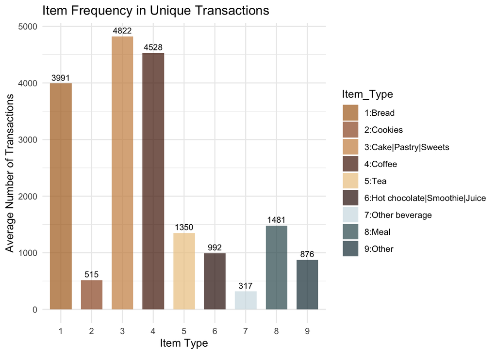

```r
df <- df %>% filter(Item!='NONE' & Item!='Adjustment')
df$Item_Type <- 9
df$Item_Type[df$Item%in%c('Bread', 'Farm House', 'Toast','Baguette','Focaccia')]<-1
df$Item_Type[df$Item == 'Cookies']<-2
df$Item_Type[df$Item%in%c('Cake','Pastry','Medialuna','Brownie','Muffin','Alfajores','Scone','Scandinavian','Truffles','Tiffin','Fudge','Jammie Dodgers','Bakewell','Tartine','Vegan mincepie')]<-3
df$Item_Type[df$Item == 'Coffee']<-4
df$Item_Type[df$Item == 'Tea']<-5
df$Item_Type[df$Item%in%c('Hot chocolate', 'Juice', 'Smoothies')]<-6
df$Item_Type[df$Item%in%c('Mineral water', 'Coke')]<-7
df$Item_Type[df$Item%in%c('Sandwich', 'Soup', 'Spanish Brunch', 'Chicken Stew', 'Salad','Frittata')]<-8
df$Item_Type<-as.factor(df$Item_Type)
df%>%group_by(Item_Type)%>%
  summarize(Count = n()) %>%
  ggplot(aes(x=Item_Type,y=Count,fill=Item_Type,label = Count)) +
  geom_bar(stat="identity", width=0.7,alpha=0.7) +
  theme_minimal() +
  scale_fill_manual(values = cookiecol,labels = c("1:Bread", "2:Cookies", "3:Cake|Pastry|Sweets",'4:Coffee','5:Tea','6:Hot chocolate|Smoothie|Juice','7:Other beverage','8:Meal','9:Other')) +
  geom_text(vjust = -0.5,size=3) +
  labs(title = 'Item Frequency in Unique Transactions', x = 'Item Type', y = 'Average Number of Transactions')
```

From the Figure above, cakes/pastries/sweets are the most popular items in the bakery, followed by Coffee and Bread.

We also want to see if the transaction of each item varies by the hours in the day. We decided to focus on bread, cookies, cake/pastry/sweets, coffee and tea.

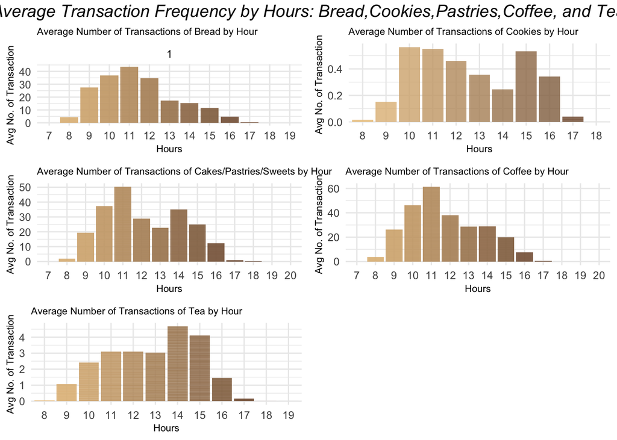

```r
bread<-df%>%filter(Item_Type==1)%>%
  group_by(as.factor(Hour))%>%
  mutate(Avg_No_of_transaction = length(unique(Transaction))/length(unique(df$Transaction))) %>%
  ggplot(aes(x = as.factor(Hour), y = Avg_No_of_transaction, fill = as.factor(Hour))) +
  geom_bar(stat = 'identity',alpha=0.8) +
  facet_wrap(~ Item_Type) +
  labs(title = 'Average Number of Transactions of Bread by Hour', x = 'Hours', y = 'Avg No. of Transaction') +
  scale_fill_manual(values = colorRampPalette(c('#ecc78d','#2e0a05'))(nb.cols)) +
  theme_minimal() +
  theme(legend.position = "none",
plot.title = element_text(size=8),
axis.title.x = element_text(size=8),
axis.title.y = element_text(size=8)
)


cookie<-df%>%filter(Item_Type==2)%>%
  group_by(as.factor(Hour))%>%
  mutate(Avg_No_of_transaction = length(unique(Transaction))/length(unique(df$Transaction))) %>%
  ggplot(aes(x = as.factor(Hour), y = Avg_No_of_transaction, fill = as.factor(Hour))) +
  geom_bar(stat = 'identity',alpha=0.8) +
  labs(title = 'Average Number of Transactions of Cookies by Hour', x = 'Hours', y = 'Avg No. of Transaction') +
  scale_fill_manual(values = colorRampPalette(c('#ecc78d','#2e0a05'))(nb.cols)) +
  theme_minimal() +
  theme(legend.position = "none",
plot.title = element_text(size=8),
axis.title.x = element_text(size=8),
axis.title.y = element_text(size=8)
)

pastry<-df%>%filter(Item_Type==3)%>%
  group_by(as.factor(Hour))%>%
  mutate(Avg_No_of_transaction = length(unique(Transaction))/length(unique(df$Transaction))) %>%
  ggplot(aes(x = as.factor(Hour), y = Avg_No_of_transaction, fill = as.factor(Hour))) +
  geom_bar(stat = 'identity',alpha=0.8) +
  labs(title = 'Average Number of Transactions of Cakes/Pastries/Sweets by Hour', x = 'Hours', y = 'Avg No. of Transaction') +
  scale_fill_manual(values = colorRampPalette(c('#ecc78d','#2e0a05'))(nb.cols)) +
  theme_minimal() +
  theme(legend.position = "none",
plot.title = element_text(size=8),
axis.title.x = element_text(size=8),
axis.title.y = element_text(size=8)
)

coffee<-df%>%filter(Item_Type==4)%>%
  group_by(as.factor(Hour))%>%
  mutate(Avg_No_of_transaction = length(unique(Transaction))/length(unique(df$Transaction))) %>%
  ggplot(aes(x = as.factor(Hour), y = Avg_No_of_transaction, fill = as.factor(Hour))) +
  geom_bar(stat = 'identity',alpha=0.8) +
  labs(title = 'Average Number of Transactions of Coffee by Hour', x = 'Hours', y = 'Avg No. of Transaction') +
  scale_fill_manual(values = colorRampPalette(c('#ecc78d','#2e0a05'))(nb.cols)) +
  theme_minimal() +
  theme(legend.position = "none",
plot.title = element_text(size=8),
axis.title.x = element_text(size=8),
axis.title.y = element_text(size=8)
)

tea<-df%>%filter(Item_Type==5)%>%
  group_by(as.factor(Hour))%>%
  mutate(Avg_No_of_transaction = length(unique(Transaction))/length(unique(df$Transaction))) %>%
  ggplot(aes(x = as.factor(Hour), y = Avg_No_of_transaction, fill = as.factor(Hour))) +
  geom_bar(stat = 'identity',alpha=0.8) +
  labs(title = 'Average Number of Transactions of Tea by Hour', x = 'Hours', y = 'Avg No. of Transaction') +
  scale_fill_manual(values = colorRampPalette(c('#ecc78d','#2e0a05'))(nb.cols)) +
  theme_minimal() +
  theme(legend.position = "none",
plot.title = element_text(size=8),
axis.title.x = element_text(size=8),
axis.title.y = element_text(size=8)
)

grid.arrange(bread,cookie,pastry,coffee,tea, nrow=3,ncol=2,
             top = textGrob("Average Transaction Frequency by Hours: Bread,Cookies,Pastries,Coffee, and Tea",gp=gpar(fontsize=14,font=3)))
```

The Figure above shows that bread and coffee on average tend to be sold more in the morning (~11am) while tea tends to be sold more in the afternoon. Transaction frequencies of cookies and cakes/pastries/sweet have peaks in both morning and afternoon.

## 3.3 The Edinburgh Weather Record

Let’s start with the high level summary of the dataset.

```r
summary(df_weather)
```

```
##       Date                 Hour          Minute               temp
##  Min.   :2016-01-01   Min.   : 0.00   Length:17544       Min.   :-8.000
##  1st Qu.:2016-07-01   1st Qu.: 5.00   Class :character   1st Qu.: 5.000
##  Median :2016-12-31   Median :11.00   Mode  :character   Median :10.000
##  Mean   :2016-12-31   Mean   :11.50                      Mean   : 9.165
##  3rd Qu.:2017-07-02   3rd Qu.:17.25                      3rd Qu.:13.000
##  Max.   :2018-01-01   Max.   :23.00                      Max.   :28.000
##
##       dwpt             rhum          prcp           snow
##  Min.   :-8.900   Min.   : 29.00   Mode:logical   Mode:logical
##  1st Qu.: 2.100   1st Qu.: 76.00   NA's:17544     NA's:17544
##  Median : 6.900   Median : 86.00
##  Mean   : 6.165   Mean   : 82.56
##  3rd Qu.:10.000   3rd Qu.: 93.00
##  Max.   :18.000   Max.   :100.00
##
##       wdir            wspd         wpgt              pres        tsun
##  Min.   : 10.0   Min.   : 0.00   Mode:logical   Min.   : 965   Mode:logical
##  1st Qu.:130.0   1st Qu.: 7.60   NA's:17544     1st Qu.:1006   NA's:17544
##  Median :240.0   Median :13.00                  Median :1014
##  Mean   :200.5   Mean   :15.04                  Mean   :1013
##  3rd Qu.:250.0   3rd Qu.:20.50                  3rd Qu.:1020
##  Max.   :360.0   Max.   :66.60                  Max.   :1040
##  NA's   :1140    NA's   :28                     NA's   :824
##       coco           station         key
##  Min.   : 5.000   Min.   :3160   Length:17544
##  1st Qu.: 7.000   1st Qu.:3160   Class :character
##  Median : 7.000   Median :3160   Mode  :character
##  Mean   : 7.139   Mean   :3160
##  3rd Qu.: 7.000   3rd Qu.:3160
##  Max.   :25.000   Max.   :3160
##  NA's   :14714
```

There are NA values in some of the columns. The columns “prcp”, “snow”, “wpgt” and “tsun” contain only NA values, so we will drop them.

The website of Meteostat gives clear explanation of each column (https://dev.meteostat.net/python/hourly.html#response-parameters):

1. station: The Meteo ID of the weather station
2. temp: The air temperature in C
3. dwpt: The dew point in C
4. rhum: The relative humidy in percent
5. wdir: The average wind direction in degrees
6. wspd: The average wind speed in km/h
7. pres: The average sea-level air pressure in hPa
8. coco: The weather condition code (https://dev.meteostat.net/docs/formats.html#weather-condition-codes). Only significant weather events are reported here.

Based on the description of each columns, we could drop the “station” column, as it remains the same for all the observations. We could also drop the “dwpt” column, as we already include the “temp” in our features. For the missing values in “coco”, we will fill 0, as it stands for non-significant weather events.

We will also remove the “Minute” column as it is always 00.

```r
df_weather <- subset(df_weather,
                     select = -c(Minute, prcp, snow, wpgt, tsun, station, dwpt))
```

For the missing values in “wdir”, “wspd”, and “pres”, considering the consistency of weather conditions, we will use the value of the hour right after.

```r
df_weather$coco[is.na(df_weather$coco)] <- 0

df_weather <- df_weather %>% tidyr::fill(wdir, .direction = "up")
df_weather <- df_weather %>% tidyr::fill(wspd, .direction = "up")
df_weather <- df_weather %>% tidyr::fill(pres, .direction = "up")
```

## 3.4 The Combined Dataset

We now will merge the two datasets based on the pre-defined keys.

```r
df_merged <- merge(x = df, y = df_weather, by = 'key', all.x = TRUE)
df_merged$Date <- df_merged$Date.x
df_merged$Hour <- df_merged$Hour.x
df_merged <- subset(df_merged,
                    select = -c(key, Time, Date.y, Hour.y, Date.x, Hour.x))
```

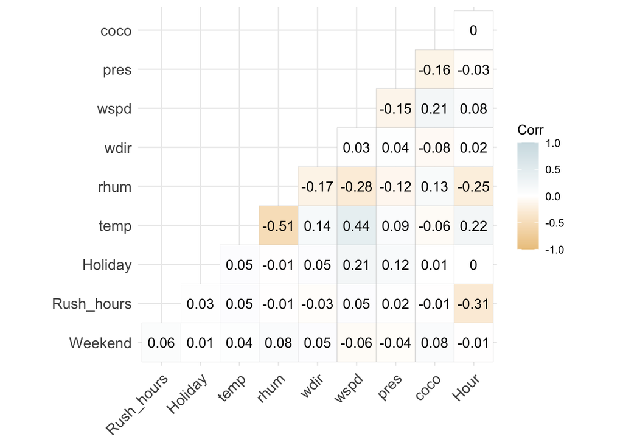

```r
df_merged_feature <- subset(df_merged, select = -c(Transaction, Item, Weekday, Item_Type, Date))
#Calculate correlation here
corr <- round(cor(df_merged_feature), digits = 2)

#Use ggcorrplot to graph correlation. Only plot the lower triangle of the correlation matrix.
ggcorrplot(corr, type = "lower",
           ggtheme = ggplot2::theme_minimal,
           lab = TRUE,
           colors = c(cookiecol[5],'white',cookiecol[7]))
```

The correlation table suggests possible correlation between the temperature and the humidity, and between the temperature and the speed of wind.

## 3.5 Dataset Construction

### 3.5.1 Predict Transactions By Date, Hour, and Weather Information

```r
# To build the dataset for the regression problem

df_merged_reg <- ddply(df_merged, .(Date, Hour), summarise, No_of_transaction = length(unique(Transaction)))

df_merged_temp <- subset(df_merged, select = -c(Transaction, Item, Item_Type))

df_merged_reg <- merge(x = df_merged_reg,
                       y = df_merged_temp,
                       by = c('Date', 'Hour'))

df_merged_reg <- distinct(df_merged_reg)

summary(df_merged_reg)
```

```
##       Date                 Hour       No_of_transaction Weekday
##  Min.   :2016-10-30   Min.   : 7.00   Min.   : 1.000    Mon:201
##  1st Qu.:2016-12-06   1st Qu.:10.00   1st Qu.: 3.000    Tue:225
##  Median :2017-01-20   Median :12.00   Median : 6.000    Wed:222
##  Mean   :2017-01-17   Mean   :12.43   Mean   : 6.326    Thu:228
##  3rd Qu.:2017-02-28   3rd Qu.:15.00   3rd Qu.: 9.000    Fri:222
##  Max.   :2017-04-09   Max.   :20.00   Max.   :25.000    Sat:226
##                                                         Sun:170
##     Weekend         Rush_hours        Holiday             temp
##  Min.   :0.0000   Min.   :0.0000   Min.   :0.00000   Min.   :-6.000
##  1st Qu.:0.0000   1st Qu.:0.0000   1st Qu.:0.00000   1st Qu.: 5.000
##  Median :0.0000   Median :1.0000   Median :0.00000   Median : 7.000
##  Mean   :0.2651   Mean   :0.7383   Mean   :0.03414   Mean   : 7.009
##  3rd Qu.:1.0000   3rd Qu.:1.0000   3rd Qu.:0.00000   3rd Qu.:10.000
##  Max.   :1.0000   Max.   :1.0000   Max.   :1.00000   Max.   :16.000
##
##       rhum             wdir            wspd            pres
##  Min.   : 31.00   Min.   : 10.0   Min.   : 0.00   Min.   : 980
##  1st Qu.: 75.00   1st Qu.:210.0   1st Qu.: 9.40   1st Qu.:1005
##  Median : 81.00   Median :240.0   Median :14.80   Median :1016
##  Mean   : 80.38   Mean   :214.1   Mean   :16.73   Mean   :1015
##  3rd Qu.: 87.00   3rd Qu.:260.0   3rd Qu.:24.10   3rd Qu.:1026
##  Max.   :100.00   Max.   :360.0   Max.   :55.40   Max.   :1039
##
##       coco
##  Min.   : 0.0000
##  1st Qu.: 0.0000
##  Median : 0.0000
##  Mean   : 0.9257
##  3rd Qu.: 0.0000
##  Max.   :17.0000
##
```

Next, we plot scatter plots of number of transaction against different weather features, respectively

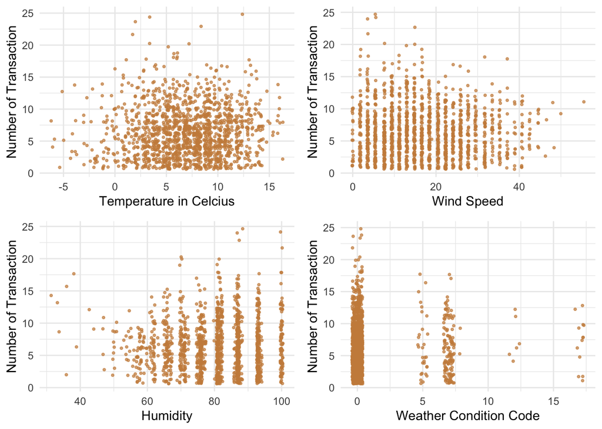

```r
# scatter plots of number of transaction against different weather features, respectively
temp<-df_merged_reg%>%ggplot(aes(temp,No_of_transaction)) +
  geom_jitter(alpha = 0.7, size=0.7, colour = cookiecol[3]) +
  labs(x='Temperature in Celcius', y='Number of Transaction') +
  theme_minimal()

ws<-df_merged_reg%>%ggplot(aes(wspd,No_of_transaction)) +
  geom_jitter(alpha = 0.7, size=0.7, colour = cookiecol[3]) +
  labs(x='Wind Speed', y='Number of Transaction') +
  theme_minimal()

hum<-df_merged_reg%>%ggplot(aes(rhum,No_of_transaction)) +
  geom_jitter(alpha = 0.7, size=0.7, colour = cookiecol[3]) +
  labs(x='Humidity', y='Number of Transaction') +
  theme_minimal()

wcc<-df_merged_reg%>%ggplot(aes(coco,No_of_transaction)) +
  geom_jitter(alpha = 0.7, size=0.7, colour = cookiecol[3]) +
  labs(x='Weather Condition Code', y='Number of Transaction') +
  theme_minimal()

grid.arrange(temp,ws,hum,wcc, nrow = 2)
```

### 3.5.2 Classify Transactions By Whether It Includes Coffee (and/or other products-to be determined)

```r
df_merged_clas <- df_merged

df_merged_clas$Coffee <- ifelse(df_merged_clas$Item == 'Coffee', 1, 0)

df_merged_clas <- ddply(df_merged_clas, ~Transaction, summarise, Has_Coffee = sum(Coffee))

df_merged_temp <- subset(df_merged, select = -c(Item, Item_Type))

df_merged_clas <- merge(x = df_merged_clas,
                       y = df_merged_temp,
                       by = 'Transaction')

df_merged_clas <- distinct(df_merged_clas)

summary(df_merged_clas)
```

```
##   Transaction     Has_Coffee     Weekday       Weekend         Rush_hours
##  Min.   :   1   Min.   :0.0000   Mon:1128   Min.   :0.0000   Min.   :0.0000
##  1st Qu.:2420   1st Qu.:0.0000   Tue:1183   1st Qu.:0.0000   1st Qu.:1.0000
##  Median :4863   Median :0.0000   Wed:1107   Median :0.0000   Median :1.0000
##  Mean   :4845   Mean   :0.4791   Thu:1248   Mean   :0.3502   Mean   :0.8696
##  3rd Qu.:7268   3rd Qu.:1.0000   Fri:1475   3rd Qu.:1.0000   3rd Qu.:1.0000
##  Max.   :9684   Max.   :1.0000   Sat:2050   Max.   :1.0000   Max.   :1.0000
##                                  Sun:1260
##     Holiday             temp             rhum             wdir
##  Min.   :0.00000   Min.   :-6.000   Min.   : 31.00   Min.   : 10.0
##  1st Qu.:0.00000   1st Qu.: 4.500   1st Qu.: 75.00   1st Qu.:210.0
##  Median :0.00000   Median : 7.000   Median : 81.00   Median :240.0
##  Mean   :0.03365   Mean   : 7.082   Mean   : 80.41   Mean   :215.5
##  3rd Qu.:0.00000   3rd Qu.:10.000   3rd Qu.: 87.00   3rd Qu.:260.0
##  Max.   :1.00000   Max.   :16.000   Max.   :100.00   Max.   :360.0
##
##       wspd            pres           coco              Date
##  Min.   : 0.00   Min.   : 980   Min.   : 0.0000   Min.   :2016-10-30
##  1st Qu.: 9.40   1st Qu.:1005   1st Qu.: 0.0000   1st Qu.:2016-12-02
##  Median :14.80   Median :1016   Median : 0.0000   Median :2017-01-18
##  Mean   :16.43   Mean   :1015   Mean   : 0.9211   Mean   :2017-01-15
##  3rd Qu.:22.30   3rd Qu.:1026   3rd Qu.: 0.0000   3rd Qu.:2017-02-26
##  Max.   :55.40   Max.   :1039   Max.   :17.0000   Max.   :2017-04-09
##
##       Hour
##  Min.   : 7.00
##  1st Qu.:10.00
##  Median :12.00
##  Mean   :12.14
##  3rd Qu.:14.00
##  Max.   :20.00
##
```

For the classification problem, we will look at the distribution of the class to see if it is imbalanced.

```r
table(df_merged_clas$Has_Coffee)
```

```
##
##    0    1
## 4923 4528
```

### 3.5.3 Study The Clusters of Transactions

On top of the database constructed during chapter 3.5.2, here we will add the number of type of items for each transaction.

```r
df_merged_cluster <- ddply(df_merged,
                           ~Transaction,
                           summarise,
                           No_Item_Type = length(unique(Item)))

df_merged_cluster <- merge(x = df_merged_cluster,
                           y = df_merged_clas,
                           by = 'Transaction')

df_merged_cluster <- distinct(df_merged_cluster)

summary(df_merged_cluster)
```

```
##   Transaction    No_Item_Type      Has_Coffee     Weekday       Weekend
##  Min.   :   1   Min.   : 1.000   Min.   :0.0000   Mon:1128   Min.   :0.0000
##  1st Qu.:2420   1st Qu.: 1.000   1st Qu.:0.0000   Tue:1183   1st Qu.:0.0000
##  Median :4863   Median : 2.000   Median :0.0000   Wed:1107   Median :0.0000
##  Mean   :4845   Mean   : 1.997   Mean   :0.4791   Thu:1248   Mean   :0.3502
##  3rd Qu.:7268   3rd Qu.: 3.000   3rd Qu.:1.0000   Fri:1475   3rd Qu.:1.0000
##  Max.   :9684   Max.   :10.000   Max.   :1.0000   Sat:2050   Max.   :1.0000
##                                                   Sun:1260
##    Rush_hours        Holiday             temp             rhum
##  Min.   :0.0000   Min.   :0.00000   Min.   :-6.000   Min.   : 31.00
##  1st Qu.:1.0000   1st Qu.:0.00000   1st Qu.: 4.500   1st Qu.: 75.00
##  Median :1.0000   Median :0.00000   Median : 7.000   Median : 81.00
##  Mean   :0.8696   Mean   :0.03365   Mean   : 7.082   Mean   : 80.41
##  3rd Qu.:1.0000   3rd Qu.:0.00000   3rd Qu.:10.000   3rd Qu.: 87.00
##  Max.   :1.0000   Max.   :1.00000   Max.   :16.000   Max.   :100.00
##
##       wdir            wspd            pres           coco
##  Min.   : 10.0   Min.   : 0.00   Min.   : 980   Min.   : 0.0000
##  1st Qu.:210.0   1st Qu.: 9.40   1st Qu.:1005   1st Qu.: 0.0000
##  Median :240.0   Median :14.80   Median :1016   Median : 0.0000
##  Mean   :215.5   Mean   :16.43   Mean   :1015   Mean   : 0.9211
##  3rd Qu.:260.0   3rd Qu.:22.30   3rd Qu.:1026   3rd Qu.: 0.0000
##  Max.   :360.0   Max.   :55.40   Max.   :1039   Max.   :17.0000
##
##       Date                 Hour
##  Min.   :2016-10-30   Min.   : 7.00
##  1st Qu.:2016-12-02   1st Qu.:10.00
##  Median :2017-01-18   Median :12.00
##  Mean   :2017-01-15   Mean   :12.14
##  3rd Qu.:2017-02-26   3rd Qu.:14.00
##  Max.   :2017-04-09   Max.   :20.00
##
```